# Bay Wheels's trip data analysis

## Preliminary Wrangling

> *We are going to analyze a Bay Wheels's trip dataset which includes data about each trip such as : duration, start time and place, end time and place and customer categories as well.*

```python
# import all packages and set plots to be embedded inline
import numpy as np
import pandas as pd
import calendar
import datetime
import matplotlib.pyplot as plt
import seaborn as sb
%matplotlib inline
```

> We will Load in our dataset and describe its properties through the questions below.

```python
#### Reading the dataset
#### Then a quick view of the first 5 rows

df = pd.read_csv('2017-fordgobike-tripdata.csv')
df.head(5)
```

|  | duration_sec | start_time | end_time | start_station_id | start_station_name | start_station_latitude | start_station_longitude | end_station_id | end_station_name | end_station_latitude | end_station_longitude | bike_id | user_type |
| --- | --- | --- | --- | --- | --- | --- | --- | --- | --- | --- | --- | --- | --- |
| 0 | 80110 | 2017-12-31 16:57:39.6540 | 2018-01-01 15:12:50.2450 | 74 | Laguna St at Hayes St | 37.776435 | -122.426244 | 43 | San Francisco Public Library (Grove St at Hyde... | 37.778768 | -122.415929 | 96 | Customer |
| 1 | 78800 | 2017-12-31 15:56:34.8420 | 2018-01-01 13:49:55.6170 | 284 | Yerba Buena Center for the Arts (Howard St at ... | 37.784872 | -122.400876 | 96 | Dolores St at 15th St | 37.766210 | -122.426614 | 88 | Customer |
| 2 | 45768 | 2017-12-31 22:45:48.4110 | 2018-01-01 11:28:36.8830 | 245 | Downtown Berkeley BART | 37.870348 | -122.267764 | 245 | Downtown Berkeley BART | 37.870348 | -122.267764 | 1094 | Customer |
| 3 | 62172 | 2017-12-31 17:31:10.6360 | 2018-01-01 10:47:23.5310 | 60 | 8th St at Ringold St | 37.774520 | -122.409449 | 5 | Powell St BART Station (Market St at 5th St) | 37.783899 | -122.408445 | 2831 | Customer |
| 4 | 43603 | 2017-12-31 14:23:14.0010 | 2018-01-01 02:29:57.5710 | 239 | Bancroft Way at Telegraph Ave | 37.868813 | -122.258764 | 247 | Fulton St at Bancroft Way | 37.867789 | -122.265896 | 3167 | Subscriber |

## Wrangling

```python
## We will make the column names all in small letters and replace any space by '_'

df.rename(columns=lambda x : x.strip().lower().replace(' ','_'),inplace = True)
```

```python
## Dropping unneeded columns
df.drop(['start_station_id'],axis=1,inplace=True)
df.drop(['end_station_id'],axis=1,inplace=True)
df.head(2)
```

|  | duration_sec | start_time | end_time | start_station_name | start_station_latitude | start_station_longitude | end_station_name | end_station_latitude | end_station_longitude | bike_id | user_type |
| --- | --- | --- | --- | --- | --- | --- | --- | --- | --- | --- | --- |
| 0 | 80110 | 2017-12-31 16:57:39.654 | 2018-01-01 15:12:50.245 | Laguna St at Hayes St | 37.776435 | -122.426244 | San Francisco Public Library (Grove St at Hyde... | 37.778768 | -122.415929 | 96 | Customer |
| 1 | 78800 | 2017-12-31 15:56:34.842 | 2018-01-01 13:49:55.617 | Yerba Buena Center for the Arts (Howard St at ... | 37.784872 | -122.400876 | Dolores St at 15th St | 37.766210 | -122.426614 | 88 | Customer |

```python
df.dtypes
```

```
duration_sec                        int64
start_time                 datetime64[ns]
end_time                   datetime64[ns]
start_station_name                 object
start_station_latitude            float64
start_station_longitude           float64
end_station_name                   object
end_station_latitude              float64
end_station_longitude             float64
bike_id                             int64
user_type                          object
dtype: object
```

```python
# Adjusting column types

# Converting time columns into its right type

df.start_time = pd.to_datetime(df.start_time)
df.end_time = pd.to_datetime(df.end_time)

## Checking the change

df.dtypes
```

```
duration_sec                        int64
start_time                 datetime64[ns]
end_time                   datetime64[ns]
start_station_name                 object
start_station_latitude            float64
start_station_longitude           float64
end_station_name                   object
end_station_latitude              float64
end_station_longitude             float64
bike_id                             int64
user_type                          object
dtype: object
```

```python
# Dealing with null values

## Getting the count of null values in each column
df.isnull().sum()
```

```
duration_sec               0
start_time                 0
end_time                   0
start_station_name         0
start_station_latitude     0
start_station_longitude    0
end_station_name           0
end_station_latitude       0
end_station_longitude      0
bike_id                    0
user_type                  0
dtype: int64
```

#### *Great, There is no null values withing our dataset which will decrease the risk of bias.*

```python
### Dealing with duplicates

## Getting the count of duplicates in our dataset

df.duplicated().sum()
```

```
0
```

#### *Our dataset is clear of duplicates*

### Modifications for analysis puposes

#### We are going to modify and add some columns for analysis purposes

```
1) Add ( hour & day & month) column for the trips starts.
2) Convert duration into minutes to be more relevant.
```

```python
# defining a function to return (( month)) when each trip had started

def get_month(x):
    return x.month

# creating a column for trip start month
df['start_month'] = df['start_time'].map(get_month)


# Checking the new column values
df.start_month.value_counts()
```

```
10    108937
9      98558
11     95612
12     86539
8      83292
7      44073
6       2689
Name: start_month, dtype: int64
```

```python
# defining a function to return (( day )) when each trip had started

df['start_day'] = df['start_time'].dt.dayofweek

def dayName(weekday):
    if weekday == 0:
        return "Monday"
    if weekday == 1:
        return "Tuesday"
    if weekday == 2:
        return "Wednesday"
    if weekday == 3:
        return "Thursday"
    if weekday == 4:
        return "Friday"
    if weekday == 5:
        return "Saturday"
    if weekday == 6:
        return "Sunday"
df[['start_day']] = df['start_day'].map(dayName)

## checking the new column values


df['start_day'].value_counts()
```

```
Tuesday      87865
Wednesday    87752
Thursday     85243
Monday       81410
Friday       81165
Saturday     50874
Sunday       45391
Name: start_day, dtype: int64
```

```python
# defining a function to return (( hour )) when each trip had started

def get_hour(x):
    return x.hour

# creating a column for trip start month
df['start_hour'] = df['start_time'].map(get_hour)


# Checking the new column values
df.start_hour.value_counts()
```

```
17    60111
8     57227
18    46088
9     45457
16    41339
15    28448
12    27448
13    27374
7     26800
19    26598
10    25217
14    24900
11    24303
20    16642
21    11993
6      8895
22     7967
23     4867
0      2606
5      2145
1      1377
2       860
4       640
3       398
Name: start_hour, dtype: int64
```

```python
# Converting column values to be in minutes
df.duration_sec=df.duration_sec / 60

# Renaming the column to be relevant
df.rename(columns = {'duration_sec':'duration_minutes'}, inplace = True)

# Checking the results
df.head(2)
```

|  | duration_minutes | start_time | end_time | start_station_name | start_station_latitude | start_station_longitude | end_station_name | end_station_latitude | end_station_longitude | bike_id | user_type | start_month | start_day | start_hour |
| --- | --- | --- | --- | --- | --- | --- | --- | --- | --- | --- | --- | --- | --- | --- |
| 0 | 1335.166667 | 2017-12-31 16:57:39.654 | 2018-01-01 15:12:50.245 | Laguna St at Hayes St | 37.776435 | -122.426244 | San Francisco Public Library (Grove St at Hyde... | 37.778768 | -122.415929 | 96 | Customer | 12 | Sunday | 16 |
| 1 | 1313.333333 | 2017-12-31 15:56:34.842 | 2018-01-01 13:49:55.617 | Yerba Buena Center for the Arts (Howard St at ... | 37.784872 | -122.400876 | Dolores St at 15th St | 37.766210 | -122.426614 | 88 | Customer | 12 | Sunday | 15 |

```python
## The nature of trips

return_count = df[df['start_station_name'] == df['end_station_name']].shape[0]
trips_count = df.shape[0]
print ("{:.2f}".format(return_count/trips_count*100) , '% of trips ended from where it had started')

no_return_count = df[df['start_station_name'] != df['end_station_name']].shape[0]
trips_count = df.shape[0]
print ("{:.2f}".format(no_return_count/trips_count*100) , "% of trips didn't end from where it had started")
```

```
3.49 % of trips ended from where it had started
96.51 % of trips didn't end from where it had started
```

### Clean Version of ourdataset

```python
display(df.shape);
display(df.columns);
```

```
(519700, 14)
```

```
Index(['duration_minutes', 'start_time', 'end_time', 'start_station_name',
       'start_station_latitude', 'start_station_longitude', 'end_station_name',
       'end_station_latitude', 'end_station_longitude', 'bike_id', 'user_type',
       'start_month', 'start_day', 'start_hour'],
      dtype='object')
```

### What is the structure of our dataset?

> Our dataset is formed of 519,700 records and 14 features.

### What is/are the main feature(s) of interest in our dataset?

> The main feature of interest in our dataset is duration.

### What features in the dataset do you think will help support our investigation into your feature(s) of interest?

> Features that will help support our investigation into duration are start_time, start_day, start_hour and start_month.

```python
## The nature of trips

return_count = df[df['start_station_name'] == df['end_station_name']].shape[0]
trips_count = df.shape[0]
print ("{:.2f}".format(return_count/trips_count*100) , '% of trips ended from where it had started')

no_return_count = df[df['start_station_name'] != df['end_station_name']].shape[0]
trips_count = df.shape[0]
print ("{:.2f}".format(no_return_count/trips_count*100) , "% of trips didn't end from where it had started")
```

```
3.49 % of trips ended from where it had started
96.51 % of trips didn't end from where it had started
```

## Univariate Exploration

```python
## Defining a function that labels plot axes and tile easily

def plotinfo( x , y , z) :
    return plt.xlabel(x , fontsize = 10),plt.ylabel(y,fontsize = 10),plt.title(z , fontsize = 20)
```

### How much do most trips last?

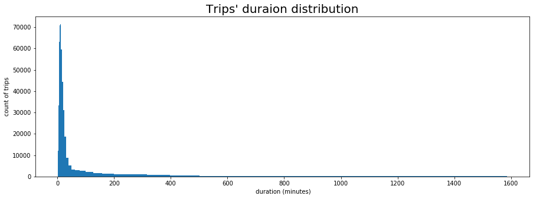

```python
### Duration histogram
plt.figure( figsize = ( 15,5));
plt.hist(data = df, x = 'duration_minutes', bins = bins);
plotinfo ( ' duration (minutes)' , 'count of trips' , "Trips' duraion distribution");
```

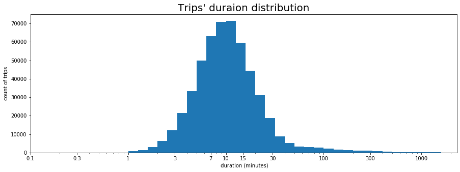

```python
### Duration histogram
plt.figure( figsize = ( 15,5));

# Transforming the scalue to overcome overplotting
bins = 10 ** np.arange(0,3.16+0.1,0.1)
ticks = [0.1 , 0.3 , 1, 3 , 7 , 10 , 15 , 30 , 100 , 300 , 1000 ]
labels = ['{}'.format(v) for v in ticks]
plt.hist(data = df, x = 'duration_minutes', bins = bins);
plt.xscale('log')
plt.xticks(ticks, labels);
plotinfo ( ' duration (minutes)' , 'count of trips' , "Trips' duraion distribution");
```

Most trips last from 5 to 20 minutes. This may be an inference that most people use bikes as quick transportation mean for only near location.

### When did most trips start ?

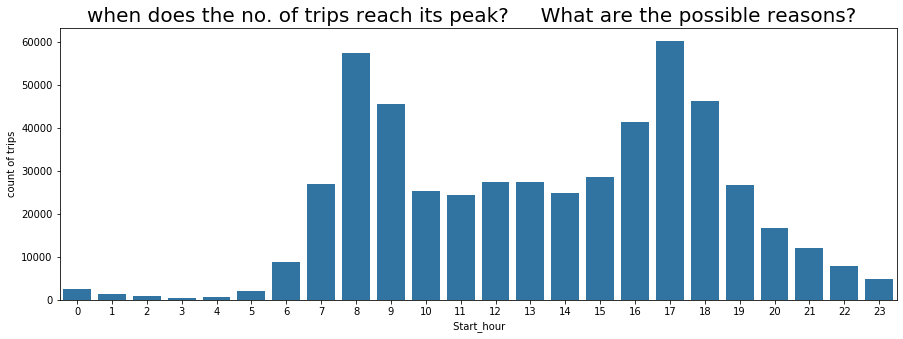

```python
### Start_hour plot
plt.figure( figsize = ( 15,5));
base_color = sb.color_palette()[0]
sb.countplot( data = df , x = 'start_hour',color = base_color );
plotinfo ( ' Start_hour' , 'count of trips' , 'when does the no. of trips reach its peak?     What are the possible reasons?  ');
```

#### *As, we can see trips count increases around 8AM and 5PM*

#### *This may be beacause people go and return from their workplaces, schools and so on at these times.*

#### *So, Bay Wheels's should make sure of bikes availability at these times in order to keep satisfying its customers.*

### Do days of week have effects on trips' count ?

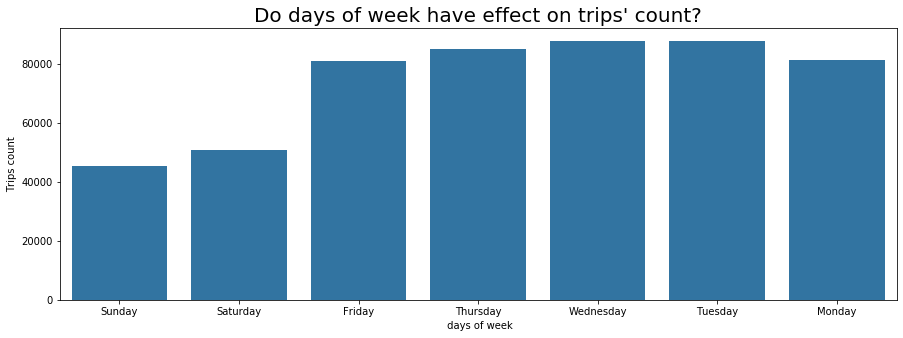

```python
## start_day

plt.figure( figsize = ( 15,5));
base_color = sb.color_palette()[0];
sb.countplot( data = df , x = 'start_day' ,color = base_color );
plotinfo(' days of week' , 'Trips count' , "Do days of week have effect on trips' count?" );
```

#### *As we can see that the number of trips experience a noticeable decrease on both "sunday and saturday". This makes sense as they are the weekly vacation .*

### What was the trips' count trend over months? WHY ?

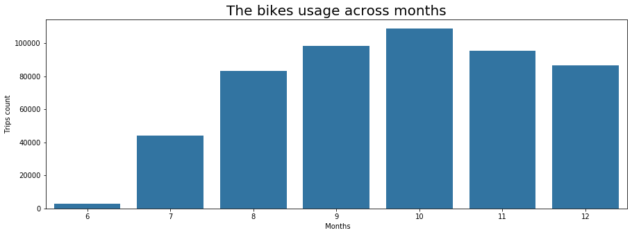

```python
## start_month plot

plt.figure( figsize = ( 15,5));
base_color = sb.color_palette()[0];
sb.countplot( data = df , x = 'start_month' ,color = base_color);
plotinfo(' Months' , 'Trips count' , "The bikes usage across months" );
```

#### *It's crystal clear that there are no trips in the period from January to May ,inclusive, In other words, No trips starts in winter, May be beacuse of snow in the streets.*

### What is Bay Wheels's more poplular user_type?

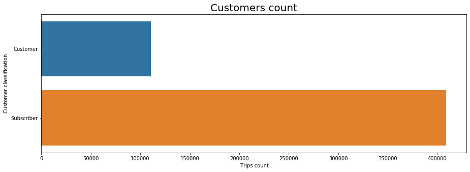

```python
## user classification plot

plt.figure( figsize = ( 15,5));
sb.countplot( data = df , y = 'user_type');
plotinfo(' Trips count' , 'Customer classification' , "Customers count" );
```

#### *The number of trips carried out by subscribers are nearly 4 times as of non-subscribers. So, Subscribers are more important for Bay Wheels's.*

#### *Also, This ratio makes sense as frequent users tend to subscribe beacause of economic perspective.*

> Make sure that, after every plot or related series of plots, that you include a Markdown cell with comments about what you observed, and what you plan on investigating next.

### Discuss the distribution(s) of your variable(s) of interest. Were there any unusual points? Did you need to perform any transformations?

1) *As we saw trips count increases around 8AM and 5PM*

2) *As we saw that the number of trips experience a noticeable decrease on both "sunday and saturday". This makes sense as they are the weekly vacation .*

3) *As we saw that the number of trips experience a noticeable decrease on both "sunday and saturday". This makes sense as they are the weekly vacation .*

4) *It's crystal clear that there are no trips in the period from January to May ,inclusive, In other words, No trips starts in winter, May be beacuse of snow in the streets.*

5) *The number of trips carried out by subscribers are nearly 4 times as of non-subscribers. So, Subscribers are more important for Bay Wheels's.*

### Of the features we investigated, There was unusual distribution in duration, So I performed operations on the data to adjust :

> In other words, There was overplotting within duration distribution, I log transform the x-axis in order to view the durations in more clear way.

## Are there significant linear relationships in our dataset ?

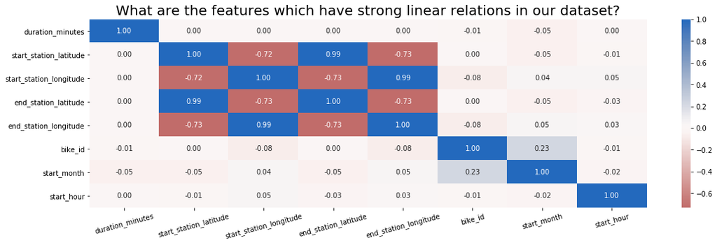

```python
## This heat map is to show the pairwise relations in our dataset
# It also help us to detect the linear relations in our datset

plt.figure( figsize = ( 18,5));
sb.heatmap(df.corr(), annot = True, fmt = '.2f', cmap = 'vlag_r', center = 0);
plt.title('What are the features which have strong linear relations in our dataset?',fontsize = 20);
plt.xticks( rotation = 15);
```

#### *There are no significant linear relations relevant to our analysis.*

### Is there a relation between the trip start_day and the trip duration ?

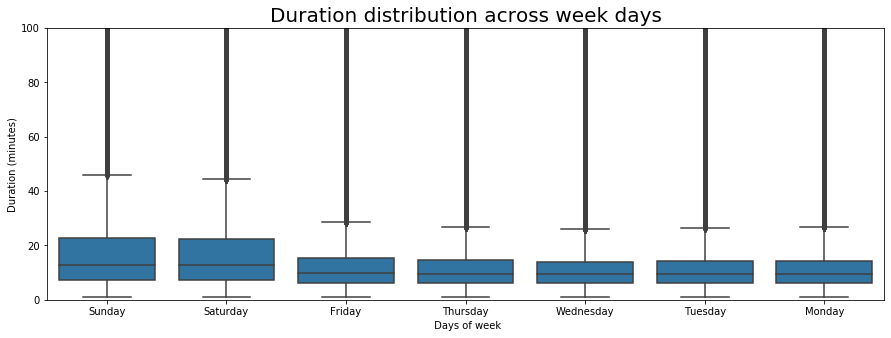

```python
# boxplot of days of week & trips' duration

plt.figure(figsize = [15, 5])
base_color = sb.color_palette()[0]
sb.boxplot(data = df, x= 'start_day', y= 'duration_minutes', color = base_color);
plt.ylim((0,100));
plotinfo(' Days of week' , 'Duration (minutes)' , "Duration distribution across week days" );
```

- *Although the number of trips on both Sunday and Saturday is reduced, The duration of trips within these days tend to be higher than average.*
- *I think this happened beacause people aren't in a hurry as workdays, So they tak their time riding the bikes.*

### Duration vs Start_month

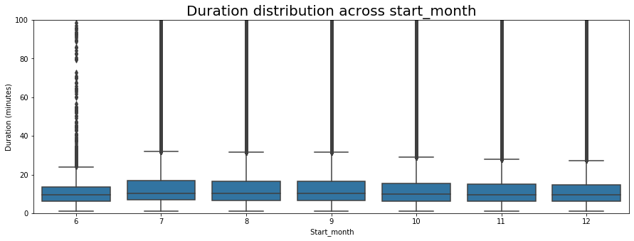

```python
# boxplot of start_month & trips' duration

plt.figure(figsize = [15, 5])
base_color = sb.color_palette()[0]
sb.boxplot(data = df, x= 'start_month', y= 'duration_minutes', color = base_color);
plt.ylim((0,100));
plotinfo(' Start_month' , 'Duration (minutes)' , "Duration distribution across start_month" );
```

#### *There is no noticeable differrence in durations according to in which month we are.*

## Does user_type have an effect trip's duration?

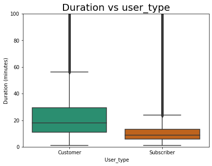

```python
## Boxplot of user_type vs duration in minutes

plt.figure(figsize = [15, 5])
base_color = sb.color_palette()[0]
plt.subplot(1, 2, 1);
sb.boxplot(data = df, x= 'user_type', y= 'duration_minutes', palette = 'Dark2');
plt.ylim((0,100));
plotinfo(' User_type' , 'Duration (minutes)' , "Duration vs user_type" );
```

#### We can conclude that:

```
1) Non-subscribers tend to ride more than subscribers.
2) Customer durations has deviation greater than that of subscribers, In other words, Subscribers duration are more         determinable than non-subscribers.
```

### How can user_type effect the trip counts ?

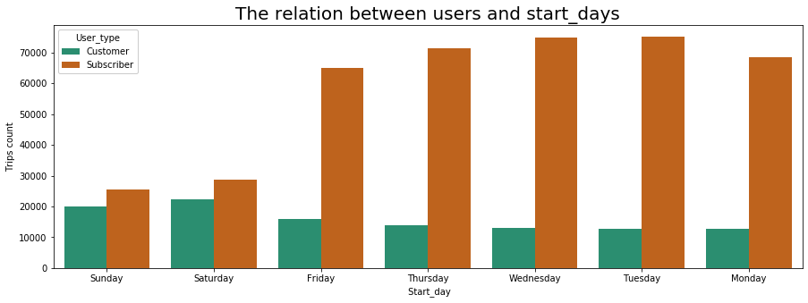

```python
# we will cluster the categorical variables
plt.figure( figsize = (15,5))
ax = sb.countplot(data = df, x = 'start_day', hue = 'user_type',palette = 'Dark2')
ax.legend( framealpha = 1, title = 'User_type')
plotinfo(' Start_day' , 'Trips count' , "The relation between users and start_days" );
```

#### *We observe the contradicting trends of both user_types:*

1) non-subscribers ride bikes more in vacation days than in workdays.

2) subscribers ride bikes more in workdays than vacation days.

3) Subscribers rides are always higher than that of non-subscribers regardless the day.

### How did the duration vary with other features in our dataset?

> On both Sunday and Saturday the duration of trips tend to be higher than average.

> Non-subscribers tend to ride more than subscribers.

### I observe an interesting relationships between the trips' count and user_types on different start_days and start_months.

> We observe a ontradicting trends of both user_types: Non-subscribers ride bikes more in vacation days than in workdays. While subscribers ride bikes more in workdays than vacation days. In all cases Subscribers rides are higher than that of non-subscribers regardless the day.

## Multivariate Exploration

### **What are the effects of user_types on both trip's duration and trip's count on different days?**

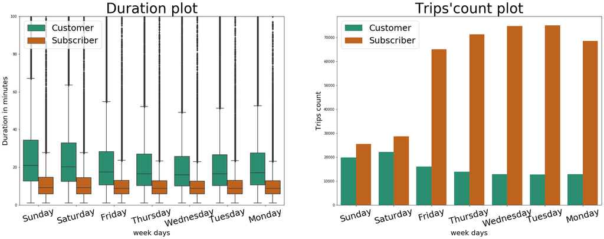

```python
## Initiating a plot

plt.figure(figsize = [30, 10]);

## Fisrt subplot:
plt.subplot(1, 2, 1);
sb.boxplot(data = df, x= 'start_day', y= 'duration_minutes',hue='user_type', palette = 'Dark2');
ax.legend( framealpha = 1, title = 'User_type');
plt.title('Duration plot',fontsize = 40);
plt.ylim((0,100));
plt.xticks(fontsize=25, rotation = 15);
plt.ylabel('Duration in minutes',fontsize = 20);
plt.xlabel('week days', fontsize = 20);
plt.legend(loc=2, prop={'size': 25});

## Second subplot
plt.subplot(1, 2, 2 );
ax = sb.countplot(data = df, x = 'start_day', hue = 'user_type',palette = 'Dark2');
ax.legend( framealpha = 1, title = 'User_type');
plt.title("Trips'count plot",fontsize = 40);
plt.ylabel('Trips count',fontsize = 20)
plt.xlabel('week days', fontsize = 20);
plt.legend(loc=2, prop={'size': 25});
plt.xticks(fontsize=25, rotation = 15);
```

#### *CONCLUSIONS*

1) The non-subscribers are often higher in terms of trips' duration

2) While subscribers are often higher in terms of trips' count.

### **What are the effects of user_types on both trip's duration and trip's count on different months?**

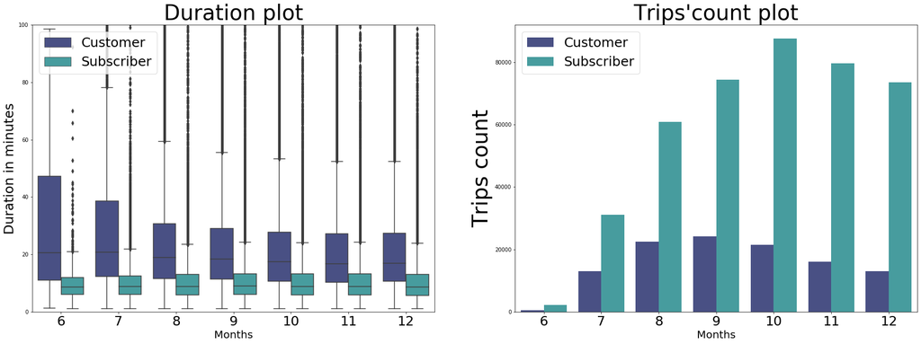

```python
## Initiating a plot

plt.figure(figsize = [30, 10]);

## Fisrt subplot:
plt.subplot(1, 2, 1);
sb.boxplot(data = df, x= 'start_month', y= 'duration_minutes',hue='user_type', palette = 'mako');
ax.legend( framealpha = 1, title = 'User_type');
plt.title('Duration plot',fontsize = 40);
plt.ylim((0,100));
plt.xticks(fontsize=25);
plt.xlabel('Months', fontsize = 20);
plt.ylabel('Duration in minutes',fontsize = 25)
plt.legend(loc=2, prop={'size': 25});

## Second subplot
plt.subplot(1, 2, 2 );
ax = sb.countplot(data = df, x = 'start_month', hue = 'user_type',palette = 'mako');
ax.legend( framealpha = 1, title = 'User_type');
plt.title("Trips'count plot",fontsize = 40);
plt.ylabel('Trips count',fontsize = 40);
plt.xlabel('Months', fontsize = 20);
plt.legend(loc=2, prop={'size': 25});
plt.xticks(fontsize=25);
```

### *This plot gives us the same results and trends for both duration and trips' count subplots. But It is noteworthy that:*

1) In June, The durations of non-subscribers rides are much higher than other months.

2) Trips' count reached its peak in October then started to fall again as winter was coming.

### Some of the relationships I observed in this part of the investigation:

1) Duration increases within customers than subscribers on both days and minths.

2) Trips duration in June increased alot by customers than other months.

3) Trips count in october reached its peak by subscribers far above by customers than other months.